# Select mobile sensors data to predict movement

## Introduction

In this case study, I’m going to talk more about exploratory data analysis techniques, and how to use them, on a data set that involves using smart phones, to, kind of, predict human activities. So remember, just any exploratory data analysis, you have to have a sense of kind of like, what you’re looking for, what might, and what might be the kind of the key priorities that you want to get outta your data set.

the data set here comes from the University of California Irvine or U.C.I. machine learning archive. And it’s based on predicting people’s movements. The actual data set was was produced using the Galaxy S2, and but the,the idea is kind of basically the same. So, in each of these’s, phones. There’s an accelerometer and a gyroscope. And so it helps you kind of, to understand the kind of three dimensional position and acceleration of a person. Assuming that they are holding their phone.

Our big challenge will be, having a huge dataset (7400 rows and 563 variables) where we could start looking at in our variables to try to identify wich of them will be important for our model, where we want to predict which movement the person is doing based on those selected variables. To train our model, will be good not to use the 562 variables.

```r
file.name <- "./RD_501_88101_1999-0.txt"
url       <- "https://archive.ics.uci.edu/ml/machine-learning-databases/00240/UCI%20HAR%20Dataset.zip"
zip.file  <- "./data.zip"

if (!file.exists(file.name)) {
  download.file(url, destfile = zip.file)
  unzip(zip.file)
  file.remove(zip.file)
}
```

```
## [1] TRUE
```

```r
xvals <- read.table("UCI HAR Dataset/train/X_train.txt")
yvals <- read.table("UCI HAR Dataset/train/y_train.txt")
features <- read.table('UCI HAR Dataset/features.txt')
subject <- read.table("UCI HAR Dataset/train/subject_train.txt")
```

he data been processed a little bit to make it a little bit easier to use. Basically you get a matrix, The, that has kind of, has the observations on the rows and the various features on columns. And you see that at the bottom here, I’ve got the activity label which is the kind of the, for each row that tells you what the person was doing at that time. And so for example there is six possible activities that you can be doing; there’s laying, sitting, standing. Walking, walking down and walking up

```r
colnames(xvals) <- features[,2]
yvals <- yvals[,1]
yvals[yvals==1]="walk"
yvals[yvals==2]="walkup"
yvals[yvals==3]="walkdown"
yvals[yvals==4]="sitting"
yvals[yvals==5]="standing"
yvals[yvals==6]="laying"

xvals$subject <- subject[,1]
xvals$activity <- yvals

samsungData <- xvals

names(samsungData)[1:12]
```

```
##  [1] "tBodyAcc-mean()-X" "tBodyAcc-mean()-Y" "tBodyAcc-mean()-Z"
##  [4] "tBodyAcc-std()-X"  "tBodyAcc-std()-Y"  "tBodyAcc-std()-Z"
##  [7] "tBodyAcc-mad()-X"  "tBodyAcc-mad()-Y"  "tBodyAcc-mad()-Z"
## [10] "tBodyAcc-max()-X"  "tBodyAcc-max()-Y"  "tBodyAcc-max()-Z"
```

```r
table(samsungData$activity)
```

```
##
##   laying  sitting standing     walk walkdown   walkup
##     1407     1286     1374     1226      986     1073
```

We can do really quickly is just to look at the average acceleration for the first subject. Convert the activity variable into a factor variable. And then using the transform function. And them I’m going to just subset out the the first subject. So subject equals one and I’m, for the rest of this presentation I’m just going to ignore the rest of the subjects for a moment. And then the second plot here is going to be the, body excel, the mean body acceleration in the y direction and, and I’ve color coded each of the, activities

And so you can see that, for example, the mean body acceleration is ah,relatively kind of uninteresting for things like sit,standing and sitting and laying. But for things like walking and working down and walking up, there’s much more variability. In the, in the mean body acceleration for the x direction.

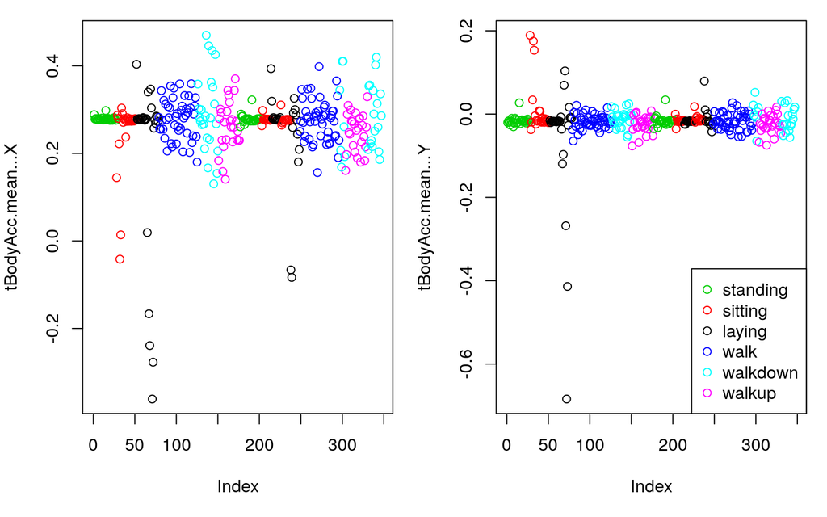

```r
par(mfrow = c(1,2),mar = c (5,4,1,1))
samsungData <- transform(samsungData,activity = factor(activity))
sub1 <- subset(samsungData,subject ==1)
plot(sub1[,1],col = sub1$activity, ylab = names(sub1)[1])
plot(sub1[,2],col = sub1$activity, ylab = names(sub1)[2])
legend("bottomright",legend = unique(sub1$activity),col = unique(sub1$activity),pch = 1)
```

Clustering based just on average acceleration. We are going to use one external function to better show the results on the dendogram. And you can see that the clustering is a little bit messy. And there isn’t any kind of clear pattern going on. All the colors are kind of jumbled together at the bottom. And so we might need to look a little bit further to try and kind of extract more information out of here.

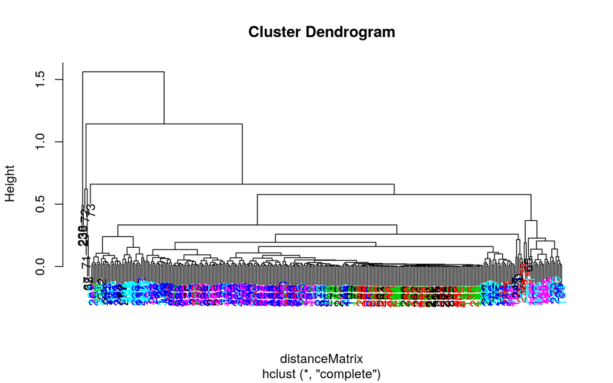

```r
source("myplclust.R")
distanceMatrix <- dist(sub1[,1:3])
hclustering <- hclust(distanceMatrix)
myplclust(hclustering, lab.col = unclass(sub1$activity))
```

A cluster based on maximum acceleration seems to separate out moving from non moving

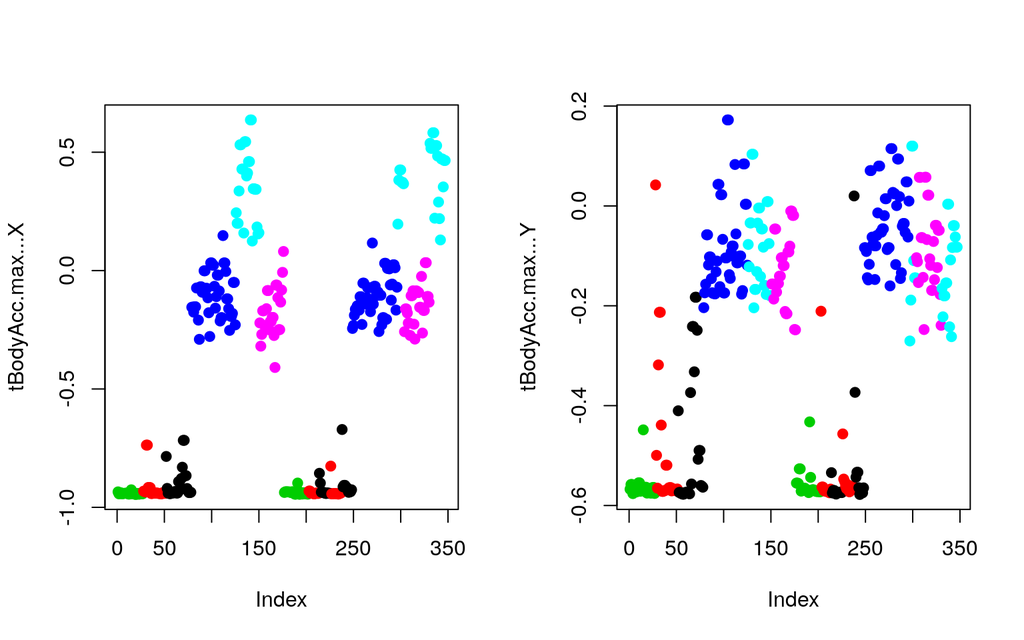

```r
par(mfrow = c(1,2))
plot(sub1[,10],pch = 19, col = sub1$activity, ylab = names(sub1)[10])
plot(sub1[,11],pch = 19, col = sub1$activity, ylab = names(sub1)[11])
```

Singular value decomposition on this data, just to explore what’s going on. I’m going to do it on the entire matrix, which is 560 something um,columns. I’m going to remove the last two, the last two columns are just the activity identifier and the subject identifier which are not real interesting data. So I, I get rid of the five, the columns 562 and 63 and then I run the SVD on the data.

first and the second left singular vectors and color code them by activity. And again, you can kind of see there’s a similar type of pattern. The first singular vector really seems to separate out the moving from the non moving. So you can see that there’s a, a kind of a green, red, black on the bottom. And the blue, turquoise, magenta on the top.

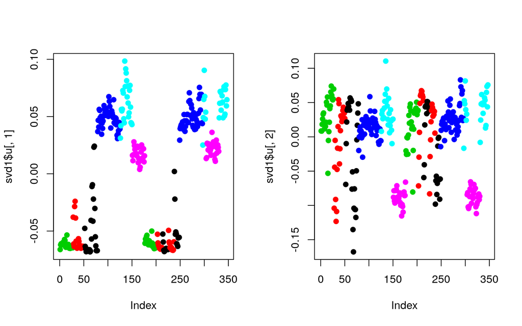

```r
svd1 = svd(scale(sub1[, -c(562,563)]))
par(mfrow = c(1,2))
plot(svd1$u[,1], col = sub1$activity,pch=19)
plot(svd1$u[,2], col = sub1$activity,pch=19)
```

One of the things we can try to do is try to find the maximum contributors,in the second right singular vector, we can try to figure out well which of these features is kind of producing the most variation, or is contributing to the most

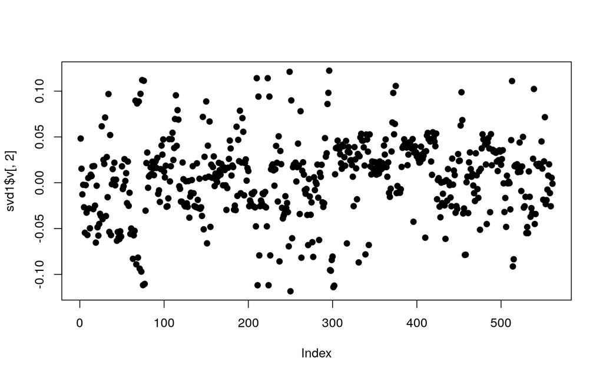

```r
plot(svd1$v[,2],pch = 19)
```

We can use the which.max function to figure out okay, which of the 500 or so features corresponds to the, the, the kind of largest, or contributes most of the variations across observations, and I say that to an object called maxContrib. And then I’ll cluster based on the maximum acceleration plus this extra feature and I’ll, and I’ll calculate the distance matrix to run the h plus function and you can see now the kind of various activities seem to be separating out a little bit more, at least the three movement activities have clearly been separated. We’ve got the magenta, the dark blue and the turquoise all separated out the various non moving activities seem to be all kind of mixed together too so the, whatever this maximum contributor happened to be it didn’t really help to separate out the non moving activities. But it seemed to help a lot in terms of separating out the movement activities.

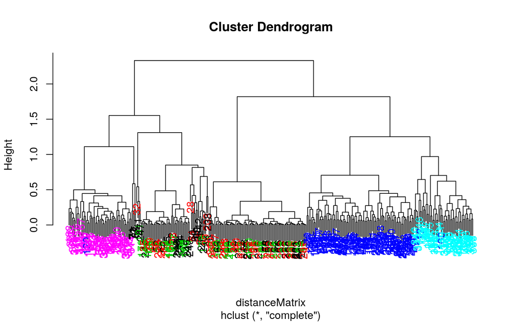

```r
maxContrib <- which.max(svd1$v[,2])
distanceMatrix <- dist(sub1[,c(10:12,maxContrib)])
hclustering <- hclust(distanceMatrix)
myplclust(hclustering, lab.col = unclass(sub1$activity))
```

We can try another clustering technique here which is K-means clustering. you have to be a little bit careful about is that you can get kind of different answers depending on, you know how many times,starting values you’ve tried and how and how often you run it so whenever you, when you start k-means it has to chose a starting point for where the cluster centers are often it will just chose, most algorithms will chose a random starting point. So if you chose a random starting point you may get to a solution that is suboptimal. So if you chose a different starting point you may get to an even better solution.